# Resumen: Modelo de Crecimiento, Solow-Swan

Daniel Pailañir

## Recordar:

- Función de Producción en términos per cápita: $y=A*k^\alpha$, donde $A>0$
- Funcióm de Ahorro: $S=\gamma * y$, donde $0<\gamma<1$
- Función de depreciación: $D=(n+\delta)*k$, donde $0<n<1$ y $0<\delta<1$.

Además conocemos la ecuación fundamental de acumulación de capital:$\bigtriangleup k=\gamma * y-(n+\delta)*k$. De esta ecuación derivamos el Estado Estacionario $(EE)$ de la economía.

Capital de $EE$:

$$k_{EE}= \left(\frac{\gamma A}{n+\delta}\right) ^{\frac{1}{1-\alpha}}$$
Producción de $EE$:

$$y_{EE}= A^{\frac{1}{1-\alpha}} \left(\frac{\gamma}{n+\delta}\right) ^{\frac{\alpha}{1-\alpha}}$$
Ahora, que ya recordamos que el $EE$ depende de cada uno de los parámetros que conforman a esta economía, veamos ejemplos gráficos al respecto.

## Caso 1: Diferencia de ahorro

En el siguiente gráfico se grafica dos $EE$ para una economía. La única diferencia entre estos estados, es únicamente la tasa de ahorro $(\gamma)$. La línea azul se construye en base a $\gamma=0.5$, o sea, en esta escenario las personas estarían ahorrando la mitad de lo que se produce en dicha economía y la curva de ahorro asociada es $S=0.5*y$. Por otro lado, en la línea celeste, el ahorro alcanza un valor de $\gamma=0.25$ y la curva de ahorro asociada es $S=0.25*y$. Notemos, que el ahorro alto, conlleva a un equilibrio de $k_{EE}=125$ y $y_{EE}=125$. En cambio un ahorro “bajo”, conlleva un equilibrio de $k_{EE}=44.19$ y $y_{EE}=88.39$. De aquí derivamos la conclusión de que en una economía ahorradora, los niveles de capital y producción per cápita, son mayores.

Es importante conocer el proceso de convergencia al nuevo $EE$.

```
## [1] "Los equilibrio son ( 125 , 125 ) y ( 44.19 , 88.39 )"
```

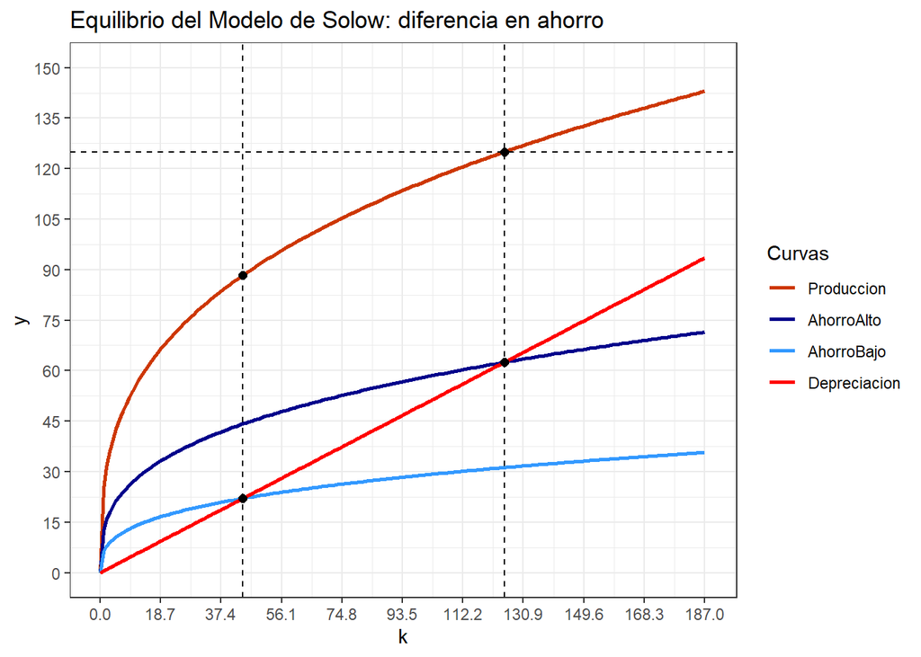

## Caso 2: Diferencia de depreciación

Otro de los casos interesantes de estudiar, es cuando varía la depreciación. Hay que recordar la composición de esta curva: $D=(n+\delta)*k$, como podemos ver depende positivamente de los parámetros de crecimiento de la población $(n)$ y la tasa de depreciación del capital $(\delta)$. Esto implica que aumentos de una de estas tasas generará que la curva de depreciación pivote en el origen y obtenga una mayor pendiente. En el siguiente gráfico se expresa lo antes mencionado.

Supongamos que la economía comenzaba con una depreciación de $\delta=0.15$ y una tasa de crecimiento de la población de $n=0.05$, con una curva de depreciación de $D=(0.05+0.15)*k$ con lo cual alcanzaba un equilibrio de $k_{EE}=30.31$ y $y_{EE}=77.95$. Ahora, considere un aumento exógeno de la depreciación a $\delta=0.25$, manteniendo los demás factores constantes. La nueva curva de depreciación es $D=(0.05+0.25)*k$ y se alcanza un equilibrio de $k_{EE}=17.46$ y $y_{EE}=64.86$. Podemos ver claramente como las cantidades de equilibrio disminuyen luego de un aumento de la depreciación, caso similiar, es si hubiese existido un aumento de la tasa de crecimiento de la población. La conclusión en este caso es: una economía con tasas de crecimiento de la población y/o tasa de depreciación alcanzará un equilibrio con menor capital y producto per cápita.

Es importante conocer el proceso de convergencia al nuevo $EE$.

```
## [1] "Los equilibrio son ( 30.31 , 77.95 ) y ( 17.46 , 64.86 )"
```

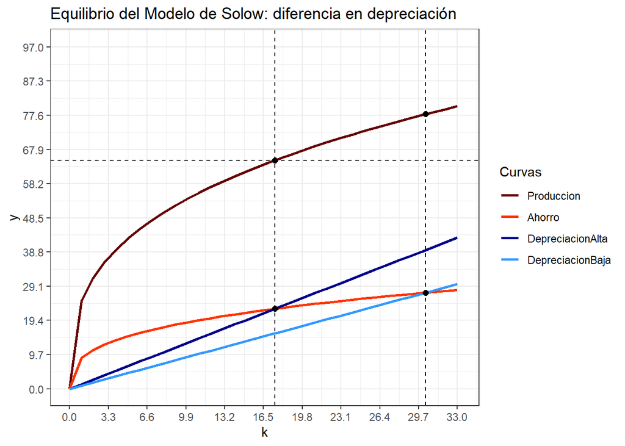

## Diferencias entre dos países

### Crecimiento de la población

Consideremos el siguiente ratio para el país $i$ y el país $j$:

$$\frac{y_i}{y_j}=\frac{A_i^{\frac{1}{1-\alpha}} \left(\frac{\gamma_i}{n_i+\delta_i}\right) ^{\frac{\alpha}{1-\alpha}}}{A_j^{\frac{1}{1-\alpha}} \left(\frac{\gamma_j}{n_j+\delta_j}\right) ^{\frac{\alpha}{1-\alpha}}}$$
Ahora, por simplicidad consideraremos:

$$A_i=A_j=A$$
$$\gamma_i=\gamma_j=\gamma$$

$$\delta_i=\delta_j=\delta$$
$$\alpha_i=\alpha_j=\alpha$$
El ratio se simplifica a :

Notemos que este analisis se puede extrapolar para encontrar las diferencias de producto por trabajador de diferencia de tasa de ahorro, depreciación del capital y nivel de tecnología.

### Diferencia de educación

Consideremos la siguiente especificación:

$$Y=AK^{\alpha}(hL)^{1-\alpha}$$

donde $h$ representa el nivel de educación de los trabajadores. Si trabajamos la expresión podemos expresarla de la siguiente manera:

$$Y=h^{1-\alpha}AK^{\alpha}L^{1-\alpha}$$
Esta expresión es similar al modelo original, lo cual nos permite proceder de la misma manera para encontrar el Estado Estacionario. El producto per cápita de $EE$ sería:

$$y_{EE}=(h^{1-\alpha}A)^{\frac{1}{1-\alpha}} \left(\frac{\gamma}{n+\delta} \right)=h \left[ A^{\frac{1}{1-\alpha}} \left(\frac{\gamma}{n+\delta} \right) \right]$$
La conclusión de esta expresión es que el producto por trabajador de Estado Estacionario, es directamente proporcional al nivel de educación de la economía.

Si procedemos al igual que el apratado anterior, podemos estudiar las diferencias de producción per cápita dados, distintos valores de educación. Si generamos un ratio entre el país $i$ y $j$, resulta:

$$\frac{y_i}{y_j}=\frac{h_i \left[ A^{\frac{1}{1-\alpha}} \left(\frac{\gamma}{n+\delta} \right) \right]}{h_j \left[ A^{\frac{1}{1-\alpha}} \left(\frac{\gamma}{n+\delta} \right) \right]}$$
Nuevamente, estamos asumiendo que los demás parámetros que definen el $EE$ son idénticos entre los países, por lo cual el ratio queda simplemente como:

$$\frac{y_i}{y_j}=\frac{h_i}{h_j}$$

### Ejemplo numérico

```
##      años rendimiento
## [1,] "4"  "14%"
## [2,] "8"  "10%"
## [3,] "12" "7%"
```

Los países quedarian:

$$h_A=(1.14)^{4}*(1.1)^{4}*(1.07)^{4}*h_0=3.24*h_0$$
$$h_B=(1.14)^{4}*h_0=1.69*h_0$$